# HW3 - Coding practice

Keanu Rochette

2025-02-03

## Load Libraries

```r
# Data manipulation and visualization
library(tidyverse)
library(here)
library(janitor)
library(ghibli)
library(RColorBrewer)
library(gt)
library(gtExtras)

# Data analysis/statistics
library(car) #ANOVA
library(ggeffects)
library(effects) #dependency for ggeffects
library(ggResidpanel) #residual panel
library(GGally)
```

## Load Data

```r
fish <- read_csv(here("HW3","data","CRCP_reef_fish.csv"))
```

```r
fish <- fish %>% clean_names()
```

```r
# I will be using the same theme elements for all my plots to I can automate it using this
nunu_theme <- theme_bw() +
  theme(plot.title = element_text(size=14, face = "bold"),
        plot.subtitle = element_text(size=12),
        axis.title = element_text(size = 12, face = "bold"),
        axis.text = element_text(size = 12),
        strip.text.x = element_text(size = 12, face = "bold"),
        legend.title=element_text(size=12, face = "bold"),
        legend.text=element_text(size=12),
        #axis.text.x = element_text(angle= 45, hjust= 1),
        panel.background = element_rect(fill = "azure1"))
```

## Question 1: summary statistics

*Identify the top twelve species in terms of these three statistics: (1) mean abundance, (2) maximum abundance, (3) standard deviation of abundance. In other words, which species are most abundant on average, which reach the highest abundances, and which have the most variable abundances?*

```r
# create a summary table with average abundance, the max count and the standard deviation
fish_summary_stats <- fish %>% group_by(taxonname) %>%
  summarize(avg = mean(count, na.rm = T),
            max_abun = max(count, na.rm = T),
            std_dev = sd(count, na.rm = T))
```

### A- Top 12 fish species in mean abundance

```r
# arrange the average abundance in decreasing order and keep the top 12
fish_summary_stats %>% arrange(desc(avg)) %>%
  head(12) %>% gt() %>%
  gt_highlight_cols(avg,  fill= "orange", alpha = 0.4)
```

| taxonname | avg | max_abun | std_dev |
| --- | --- | --- | --- |
| Chromis vanderbilti | 30.403158 | 500 | 52.739959 |
| Chromis agilis | 18.994337 | 500 | 41.747309 |
| Acanthurus nigrofuscus | 6.220833 | 60 | 5.992918 |
| Ctenochaetus strigosus | 6.114540 | 60 | 6.474907 |
| Zebrasoma flavescens | 5.026948 | 52 | 5.997327 |
| Lutjanus kasmira | 4.865693 | 600 | 31.516812 |
| Paracirrhites arcatus | 2.948040 | 72 | 3.781925 |
| Pristiapogon kallopterus | 2.600000 | 5 | 1.673320 |
| Chromis hanui | 2.560062 | 200 | 10.644683 |
| Acanthurus leucopareius | 2.466069 | 40 | 4.192232 |
| Thalassoma duperrey | 2.324507 | 25 | 2.189707 |
| Decapterus macarellus | 1.840067 | 150 | 9.357235 |

### B- Top 12 fish species in max abundance

```r
# arrange the max abundances in decreasing order and keep the top 12
fish_summary_stats %>% arrange(desc(max_abun)) %>%
  head(12) %>% gt() %>%
  gt_highlight_cols(max_abun,  fill= "orange", alpha = 0.4)
```

| taxonname | avg | max_abun | std_dev |
| --- | --- | --- | --- |
| Lutjanus kasmira | 4.8656934 | 600 | 31.516812 |
| Chromis agilis | 18.9943375 | 500 | 41.747309 |
| Chromis vanderbilti | 30.4031579 | 500 | 52.739959 |
| Chromis hanui | 2.5600624 | 200 | 10.644683 |
| Chromis ovalis | 1.1048110 | 150 | 9.452354 |
| Decapterus macarellus | 1.8400673 | 150 | 9.357235 |
| Spratelloides delicatulus | 0.5902778 | 150 | 7.956327 |
| Chromis verater | 0.7109244 | 100 | 4.584831 |
| Pseudocheilinus evanidus | 1.8388889 | 100 | 5.922695 |
| Mulloidichthys vanicolensis | 0.8115450 | 90 | 4.903504 |
| Apogon kallopterus | 0.2229965 | 86 | 3.625452 |
| Chromis leucura | 0.4179620 | 80 | 4.051753 |

### C- Top 12 fish species in highest standard deviation

```r
# arrange the standard deviations in decreasing order and keep the top 12
fish_summary_stats %>% arrange(desc(std_dev)) %>%
  head(12) %>% gt() %>%
  gt_highlight_cols(std_dev,  fill= "orange", alpha = 0.4)
```

| taxonname | avg | max_abun | std_dev |
| --- | --- | --- | --- |
| Chromis vanderbilti | 30.4031579 | 500 | 52.739959 |
| Chromis agilis | 18.9943375 | 500 | 41.747309 |
| Lutjanus kasmira | 4.8656934 | 600 | 31.516812 |
| Chromis hanui | 2.5600624 | 200 | 10.644683 |
| Chromis ovalis | 1.1048110 | 150 | 9.452354 |
| Decapterus macarellus | 1.8400673 | 150 | 9.357235 |
| Spratelloides delicatulus | 0.5902778 | 150 | 7.956327 |
| Ctenochaetus strigosus | 6.1145405 | 60 | 6.474907 |
| Zebrasoma flavescens | 5.0269483 | 52 | 5.997327 |
| Acanthurus nigrofuscus | 6.2208333 | 60 | 5.992918 |
| Pseudocheilinus evanidus | 1.8388889 | 100 | 5.922695 |
| Myripristis kuntee | 1.1003289 | 54 | 4.920602 |

## Question 2: Depth

**Using the top twelve species based on mean abundance, plot a scatterplot of count vs. depth (the column is named ‘depth’). Add a smoother to help visualize mean count vs. depth, put all twelve species on a single plot (with twelve panels), and make sure each panel is titled using the species name. Furthermore, do not arrange the panels in alphabetical order — instead, arrange them in order of mean abundance, so that the most abundant species is in the top left panel, and remaining panels are in order of mean abundance. Do it in a for loop and in ggplot.**

```r
# arrange the average abundance in decreasing order and keep the top 12 name of fish species
top_avg_abun <- fish_summary_stats %>% arrange(desc(avg)) %>%
  head(12) %>%  pull(taxonname)
```

### Graph with a for loop

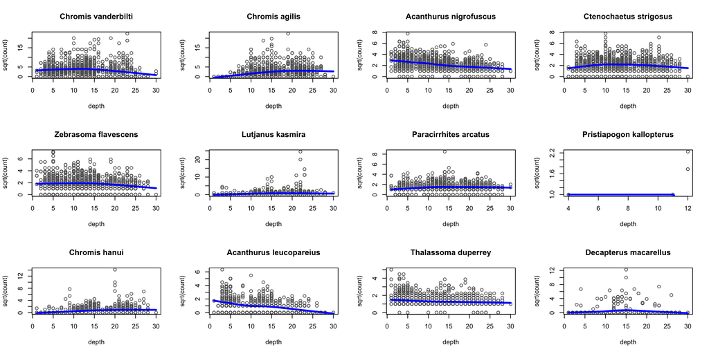

```r
#for loop to graph the correlation between fish count and depth

par(mfrow= c(3,4)) #creates a panel of 3cols x 4rows figure
for(i in 1:length(top_avg_abun)){

  data <- fish[fish$taxonname == top_avg_abun[i],] #filters the fish species based on their order form highest to lowest average abundance

  plot(sqrt(count) ~ depth, data = data, # sqrt transform the count and compare to depth
       col = "#616161", # change color of the points
       main = top_avg_abun[i]) # specify the title of the plot to be fish species name

   with(data, lines(loess.smooth(depth,sqrt(count)), col = "blue", lwd = 3))
   # creates the trend line with specific color and linewidth

}
```

### Graphing with ggplot

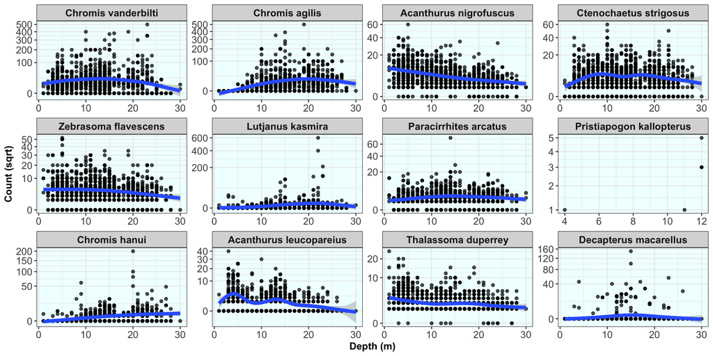

```r
#plot the correlation between fish count and depth with ggplot

fish %>% filter(taxonname %in% top_avg_abun) %>%
  mutate(taxonname = fct_reorder(taxonname,
                                 .x= count, .fun = mean,
                                 .desc = TRUE)) %>%
  ggplot(aes(x= depth, y = count)) +
  geom_point(alpha = 0.7)  +
  geom_smooth(linewidth = 2)+
  facet_wrap(.~taxonname, scales = "free")+
 scale_y_sqrt() +
  labs(x= "Depth (m)",
       y = "Count (sqrt)")+
  nunu_theme
```

```r
# name of the top 12 fish species
top_avg_abun
```

```
##  [1] "Chromis vanderbilti"      "Chromis agilis"
##  [3] "Acanthurus nigrofuscus"   "Ctenochaetus strigosus"
##  [5] "Zebrasoma flavescens"     "Lutjanus kasmira"
##  [7] "Paracirrhites arcatus"    "Pristiapogon kallopterus"
##  [9] "Chromis hanui"            "Acanthurus leucopareius"
## [11] "Thalassoma duperrey"      "Decapterus macarellus"
```

## Question 3

```r
# create a vector that keep only the name of the top 5 most abundant fish species on average
top_abun_fish <- fish_summary_stats %>% arrange(desc(avg)) %>%
  head(5) %>%  pull(taxonname)
```

### A- Plotting the most abundant species (on average)

*Make a new plot that shows abundance vs. depth for the top 5 species, including smoothers, but this time put all of the species on the same scatterplot and distinguish them with different colors. This time you don’t need to use two different approaches to make the plot — one approach will suffice. What is your interpretation of this plot?*

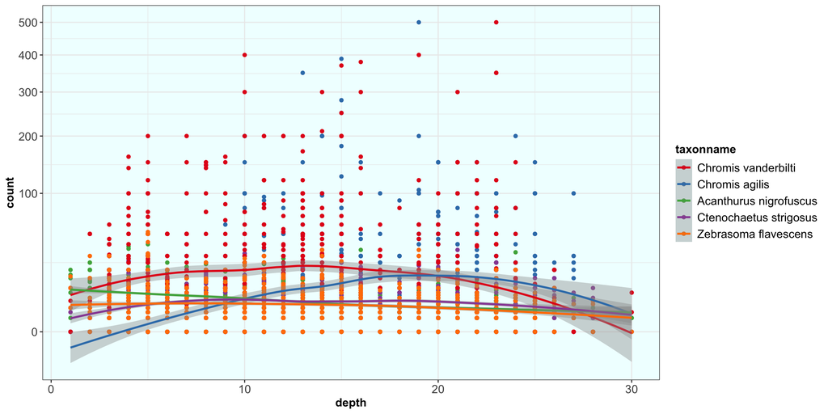

```r
fish %>% filter(taxonname %in% top_abun_fish) %>% #keeping only the top 12 most abundant fish
  mutate(taxonname = fct_reorder(taxonname,
                                 .x= count, .fun = mean,
                                 .desc = TRUE)) %>% #order the taxoname by abundance
  ggplot(aes(x= depth, y = count,
             color = taxonname, group = taxonname))+
  geom_point()+
  geom_smooth(method = "loess")+ # choose smoothing method
  scale_color_brewer(palette = "Set1")+ # choose colot palette
  scale_y_sqrt()+ # sqrt transform the y axis
  nunu_theme
```

#### Answer

Looking at the trend lines, it looks like fish species have different depth preference. It appears to be sequential as well.

- **Chromis vanderbilti**’s abundance is more correlated to the surface (0-20m).
- **Chromis agilis**’s abundance correlates with deeper depth (15-25m).
- **Ctenochaetus strigosus** also prefers mid to deeper depth, with a maximum at around 20m, but the overall trend it fairly flat.
- **Zebrasoma flavescens** & **Acanthurus nigrofuscus**’s abundances does not seem to correlate with a particular depth.

### B- Linear model

*Fit a linear model that tests whether these 5 species have different depth niches. Based on residual diagnostic plots of this model, and a plot of the fitted effects, do you think a linear model is a good approach for testing this question? If not, why not?*

```r
top_5_fish <- fish %>% filter(taxonname %in% top_abun_fish) #only keep the top 5 fish species
```

```r
#setting up a linear model. depth and taxonname are predictors and sqrt(count) is a response variable
top_fish_lm <- lm(sqrt(count) ~ depth*taxonname, data= top_5_fish)

summary(top_fish_lm)
```

```
##
## Call:
## lm(formula = sqrt(count) ~ depth * taxonname, data = top_5_fish)
##
## Residuals:
##     Min      1Q  Median      3Q     Max
## -5.4061 -1.0797 -0.1661  0.7740 18.7876
##
## Coefficients:
##                                        Estimate Std. Error t value Pr(>|t|)
## (Intercept)                            3.015428   0.116761  25.826  < 2e-16 ***
## depth                                 -0.061822   0.008293  -7.455 1.03e-13 ***
## taxonnameChromis agilis               -2.608629   0.207163 -12.592  < 2e-16 ***
## taxonnameChromis vanderbilti           1.489440   0.186598   7.982 1.71e-15 ***
## taxonnameCtenochaetus strigosus       -0.883369   0.172746  -5.114 3.26e-07 ***
## taxonnameZebrasoma flavescens         -0.753777   0.173740  -4.339 1.46e-05 ***
## depth:taxonnameChromis agilis          0.228467   0.013649  16.739  < 2e-16 ***
## depth:taxonnameChromis vanderbilti     0.032614   0.013274   2.457   0.0140 *
## depth:taxonnameCtenochaetus strigosus  0.061114   0.011882   5.143 2.79e-07 ***
## depth:taxonnameZebrasoma flavescens    0.033972   0.011983   2.835   0.0046 **
## ---
## Signif. codes:  0 '***' 0.001 '**' 0.01 '*' 0.05 '.' 0.1 ' ' 1
##
## Residual standard error: 2.107 on 6094 degrees of freedom
## Multiple R-squared:  0.1514, Adjusted R-squared:  0.1502
## F-statistic: 120.8 on 9 and 6094 DF,  p-value: < 2.2e-16
```

```r
# Anova show significant differences between fish species and in the interaction between taxonname and depth
Anova(top_fish_lm)
```

```
## Anova Table (Type II tests)
##
## Response: sqrt(count)
##                  Sum Sq   Df  F value Pr(>F)
## depth               1.4    1   0.3055 0.5805
## taxonname        3444.1    4 193.9081 <2e-16 ***
## depth:taxonname  1376.0    4  77.4693 <2e-16 ***
## Residuals       27059.9 6094
## ---
## Signif. codes:  0 '***' 0.001 '**' 0.01 '*' 0.05 '.' 0.1 ' ' 1
```

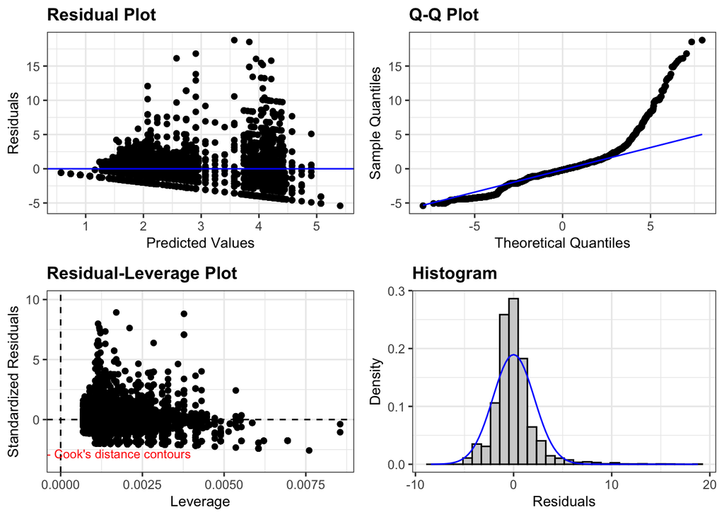

```r
# plot the residuals
resid_panel(top_fish_lm, plots = c("resid", "qq", "lev", "hist"))
```

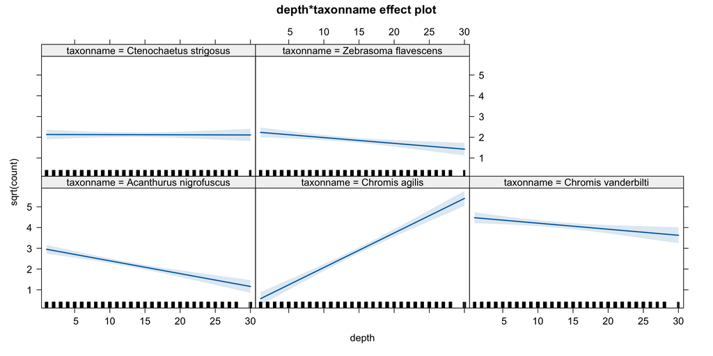

```r
# plot the effects plot
plot(allEffects(top_fish_lm, terms = c("depth", "taxonname")))
```

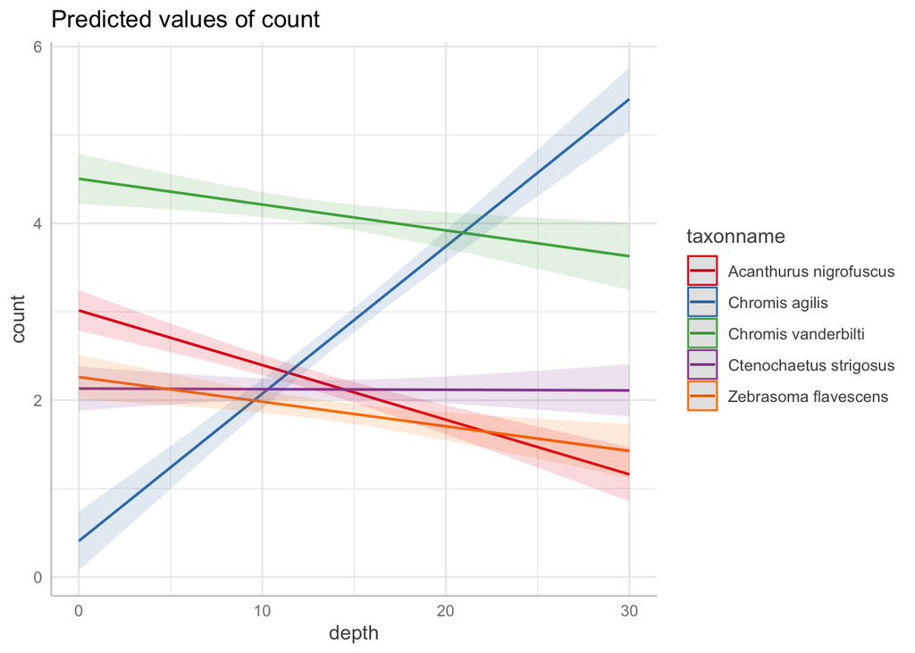

```r
# plot the effects plot

plot(ggeffect(top_fish_lm, terms = c("depth", "taxonname")))
```

#### Answer

A linear model might not be the best statistical tool to understand the distribution of fish species with depth.  
The residual plot* show that the residual points are not evenly distributed on each side of the line which may indicate that the data point are not independent from one another.  
The Q-Q plot** shows that the residual points do not follow a regression line.  
The **histogram** shows that the data is not distributed normally.